# Market Analysis of Bird-Based Tourism Using ebird Database

#### eBird is an online database of bird observation trips (checklists) providing scientists and naturalists with information about bird distribution and abundance.

### Questions:

### 1. Which metric can we use to measure the popularity of bird watching in different counties?

### 2. How can we design successful birding tours?

### 3. What demographic/ economic factors contribute to the popularity of bird watching?

```r
# Import libraries. Read files.
library(auk)
library(tidycensus)
library(tidyverse)
library(readxl)
library(urbnmapr)
library(gridExtra)
library(ggplot2)
library(corrplot)
library(modelr)
library(ranger)
library(gbm)
library(caret)
library(pdp)
library(lubridate)
library(ggmap)
library(gridExtra)
```

### 1. Which metric can we use to measure the popularity of bird watching in different counties?

#### 1.1 Get the dataset

```r
#read and filter checklists for 2018-2020 https://ebird.org/science/download-ebird-data-products
checklists_filters <- auk_sampling('F:/ebd_sampling_relMar-2020/ebd_sampling_relMar-2020.txt', sep = "\t") %>%
                      auk_date(date = c("2018-01-01", "2019-12-31")) %>% auk_country("United States") %>% auk_filter(file = 'filtered_checklist.txt')
checklists_raw <- read_sampling(checklists_filters,unique = TRUE)

checklists_raw <- checklists_raw %>%
  select(checklist_id,state,county,county_code,observation_date,time_observations_started)

#get county level population, gender, age, race, citizen, income from US Census Bureau  https://www.census.gov/data/developers/data-sets/ACS-supplemental-data.html
census_raw <- get_acs(geography = "county",
              variables = c(population = "B01003_001", male='B01001_002',female='B01001_026',median_age='B01002_001',
                            white='B02001_002',black='B02001_003',native='B02001_004',asian='B02001_005',pacific='B02001_006'                                                           ,nonecitizen='B05001_006',incomepercapita='B19301_001'),
                            year = 2018, output = "wide") %>% select(-ends_with("M"))
```

#### 1.2 Data cleaning, preprocessing

```r
checklist_county_num <- checklists_raw %>%
  group_by(state,county,county_code) %>% count(name='checklist_n') %>% ungroup() %>%  drop_na()

#Feature transformation
census_raw <- census_raw %>%
  mutate(male=maleE/populationE, female=femaleE/populationE, white=whiteE/populationE,     black=blackE/populationE,native=nativeE/populationE,asian=asianE/populationE, pacific=pacificE/populationE,otherrace=1-white-black-native-asian-pacific,citizen=1-nonecitizenE/populationE) %>%
  select(-(maleE:femaleE),-(whiteE:nonecitizenE))

#Employment statistics from Department of Labor, Education level from USDA
unemployment_raw <- read_xlsx('D:/ebird/data/birding_market/bls_laucnty18_labor.xlsx') %>%
  unite("FIPS", c('State FIPS','county FIPS'),sep = '') %>%
  mutate(unemployment_p=`Unemployment rate(%)`) %>%
  select(-'Unemployment rate(%)')

#https://www.ers.usda.gov/data-products/county-level-data-sets/
education_raw <- read_xls('D:/ebird/data/birding_market/Education_USDA.xls') %>%
  mutate(FIPS=`FIPS Code`) %>% select(-`FIPS Code`)

census_raw <- census_raw %>%
  inner_join(unemployment_raw,by = c("GEOID" = "FIPS")) %>%
  inner_join(education_raw,by = c("GEOID" = "FIPS")) %>%
  mutate(county_fips=substr(GEOID, start = 3, stop = 5)) %>%
  separate(NAME,c(NA,'state'),sep=', ') %>%
            select(-c(County,'Area name'))

#https://github.com/birderboone/birderboone.github.io/blob/master/ebirdSpeciesModeled.csv
species_n <- read.csv('D:/ebird/data/birding_market/ebirdSpecies.csv')

checklist_county_num <- checklist_county_num %>% separate(county_code,c(NA,NA,'county_fips'),sep='-')

census_ebird_raw <- left_join(checklist_county_num,census_raw, by=c("state",'county_fips')) %>%
  mutate(county=tolower(county)) %>%
  left_join(species_n, by=c('State'='state','county'))
```

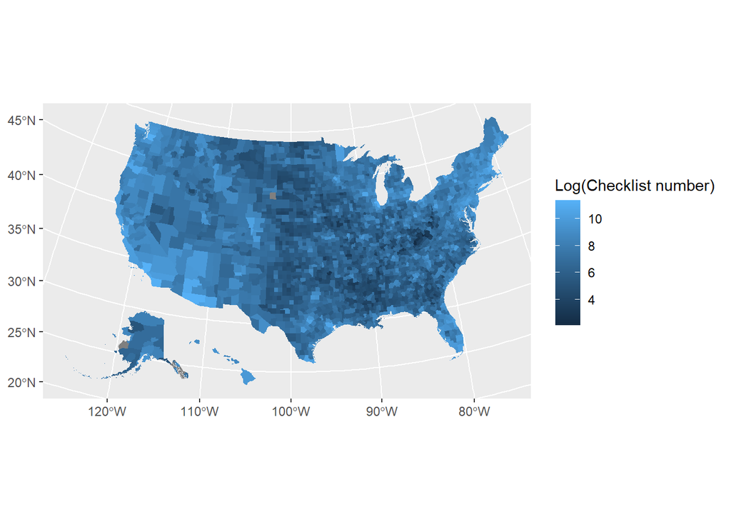

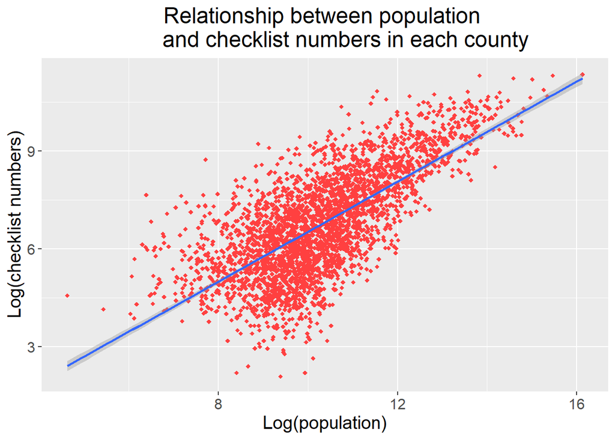

```r
ggplot(census_ebird_raw %>% drop_na(), aes(x=log(populationE), y=log(checklist_n))) +
  geom_point(shape=18, color="brown1")+
  geom_smooth(method=lm)+
  labs(title="Relationship between population
       and checklist numbers in each county",
       x="Log(population)", y = "Log(checklist numbers)")+
  theme(plot.title = element_text(hjust = 0.5),text = element_text(size=15))
```

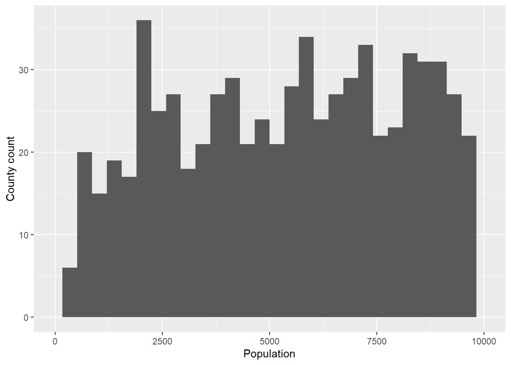

```r
ggplot(census_ebird_raw, aes(x=populationE)) +
  geom_histogram()+
  xlim(0, 10000)+
  ylab("County count")+
  xlab("Population")
```

```r
census_ebird_filtered <- census_ebird_raw %>%
  filter(populationE>=2000)
```

#### 1.3 Use checklists per person as a measurement for the popularity of bird watching in each county

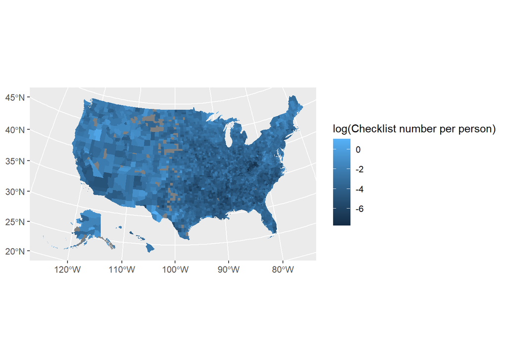

```r
census_ebird_filtered <- census_ebird_filtered %>%
  mutate(checklist_pps=checklist_n/populationE)

counties_sf %>% left_join(census_ebird_filtered %>%
                            select(state,county_fips,checklist_pps), by = c("state_name"='state','county_fips')) %>%
  ggplot() +
  geom_sf(mapping = aes(fill = log(checklist_pps)),
          color = NA, size = 0.05) +
  labs(fill = "log(Checklist number per person)")
```

### 2. Where should we start the business and how to design a successful product?

#### 2.1 Select the candidate county

```r
census_ebird_filtered_des <- readRDS("D:/ebird/data/birding_market/import_rawdata/census_ebird_filtered.rds")
census_ebird_filtered_des <- census_ebird_filtered_des %>% filter(populationE>=10000) %>%   #Population more than 10000
  select(state,county,checklist_n,populationE,totalSpSeen,checklist_pps) %>%
  arrange(desc(checklist_pps))
census_ebird_filtered_des
```

| state | county | checklist_n | populationE | totalSpSeen | checklist_pps |
| --- | --- | --- | --- | --- | --- |
| New Mexico | los alamos | 12556 | 18356 | 280 | 0.6840270211 |
| Arizona | santa cruz | 31558 | 46584 | 425 | 0.6774428988 |
| California | mono | 8415 | 14174 | 365 | 0.5936926767 |
| Virginia | northampton | 6507 | 11957 | 412 | 0.5442000502 |
| Illinois | menard | 6599 | 12367 | 241 | 0.5335974772 |
| New Mexico | socorro | 8769 | 17000 | 405 | 0.5158235294 |
| New York | tompkins | 50968 | 102962 | 330 | 0.4950175793 |
| Massachusetts | nantucket | 5439 | 11101 | 365 | 0.4899558598 |
| Maine | hancock | 25075 | 54541 | 327 | 0.4597458792 |
| New Jersey | cape may | 42552 | 93705 | 418 | 0.4541059709 |

[output cut: 2433 more lines]

#### 2.2 Read the checklist information from Arizona Santa Cruz county

```r
checklists_sc <- checklists_raw %>%
  filter(state=='Arizona',county=='Santa Cruz') %>%
  select("checklist_id","observation_date","time_observations_started","duration_minutes", "effort_distance_km",'latitude','longitude') %>%
  distinct()
```

```r
#Convert hh:mm:ss to decimal time
time_to_decimal <- function(x) {
  x <- hms(x, quiet = TRUE)
  hour(x) + minute(x) / 60 + second(x) / 3600
}

checklists_sc <- checklists_sc %>%
  mutate(time_observations_started = time_to_decimal(time_observations_started),
  day_of_year = yday(observation_date), month_of_year=month(observation_date), weekday=wday(observation_date)) %>%
  drop_na()
```

#### 2.3 People’s favorite months and days for bird watching

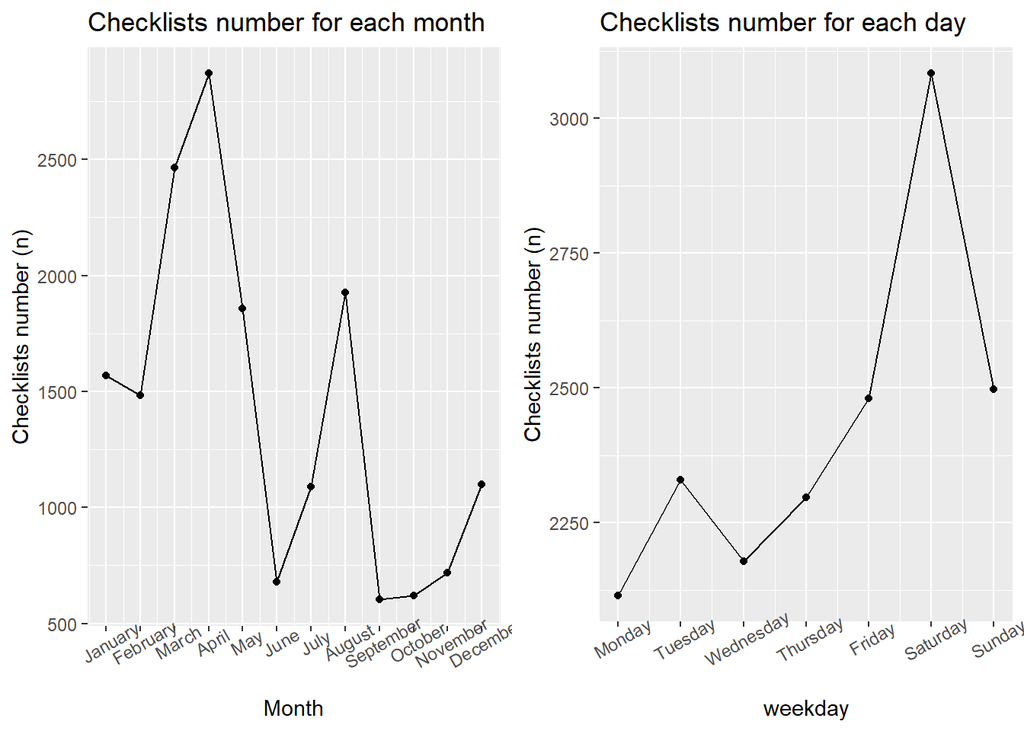

```r
# summarize data by hourly bins
month_n <- checklists_sc %>%
  group_by(month_of_year) %>%
  summarise(n_checklists = n())

month_fig <- ggplot(month_n) +
  aes(x = month_of_year, y = n_checklists) +
  geom_line() +
  geom_point() +
  labs(x = "Month",
       y = "Checklists number (n)",
       title = "Checklists number for each month") +
  scale_x_continuous(breaks = 1:12,labels = c('January', 'February', 'March', 'April', 'May', 'June', 'July', 'August', 'September', 'October', 'November', 'December'))+
  theme(axis.text.x = element_text(angle = 30))

weekday_n <- checklists_sc %>%
  group_by(weekday) %>%
  summarise(n_checklists = n()) %>%
  ungroup() %>%
  mutate(weekday=weekday-1) %>%
  mutate(weekday=ifelse(weekday==0, 7,weekday))

weekday_fig <- ggplot(weekday_n) +
  aes(x = weekday, y = n_checklists) +
  geom_line() +
  geom_point() +
  labs(y = "Checklists number (n)",
       title = "Checklists number for each day") +
  scale_x_continuous(breaks = 1:7,labels=c("Monday", "Tuesday", "Wednesday", "Thursday", "Friday", "Saturday", "Sunday")) +
    theme(axis.text.x = element_text(angle = 30))

# combine
grid.arrange(month_fig, weekday_fig, nrow=1)
```

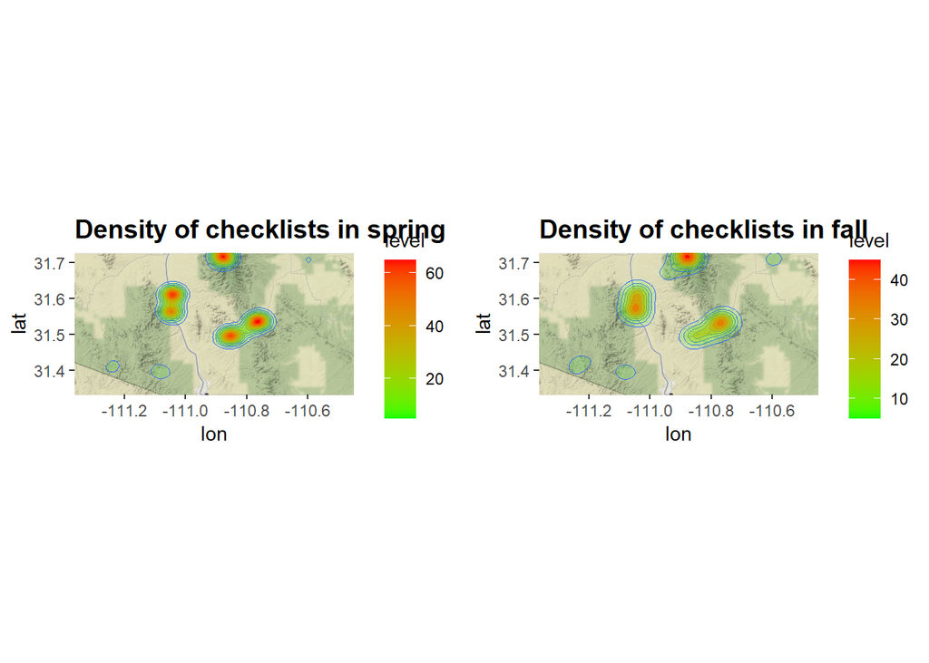

```r
#Latitude and longitude of sf found through https://www.latlong.net/
sc_map <- get_stamenmap(bbox = c(left = -111.363808, top=31.727364, bottom=31.331352, right=-110.448482), zoom = 10)

checklist_spring <- checklists_sc %>% filter(month_of_year%in%c(3,4,5))

map_spring <- ggmap(sc_map) +
  #contour
  geom_density2d(data = checklist_spring, aes(x = longitude, y = latitude), size = 0.3)+
  #fill in the color according to density
  stat_density2d(data = checklist_spring, aes(x = longitude, y = latitude, fill = ..level.., alpha = ..level..), geom = "polygon") +
  scale_fill_gradient(low = "green", high = "red") +
  scale_alpha(range = c(0.1, 1), guide = FALSE)+
  theme(plot.title = element_text(size = 14, face = "bold"))+
  labs(title = "Density of checklists in spring")

checklist_fall <- checklists_sc %>% filter(month_of_year%in%c(7,8,9))

map_fall <- ggmap(sc_map) +
  #contour
  geom_density2d(data = checklist_fall, aes(x = longitude, y = latitude), size = 0.3)+
  #fill in the color according to density
  stat_density2d(data = checklist_fall, aes(x = longitude, y = latitude, fill = ..level.., alpha = ..level..), geom = "polygon") +
  scale_fill_gradient(low = "green", high = "red") +
  scale_alpha(range = c(0.1, 1), guide = FALSE) +
  theme(plot.title = element_text(size = 14, face = "bold"))+
  labs(title = "Density of checklists in fall" )

grid.arrange(map_spring, map_fall, nrow=1)
```

#### 2.4 People’s preference for start time and trip duration

[figure not shown]

```r
breaks <- 0:24
labels <- breaks[-length(breaks)] + diff(breaks) / 2
starttime_n <- checklists_sc %>%
  mutate(startt = cut(time_observations_started,
                         breaks = breaks,
                        labels = labels,
                         include.lowest = TRUE),
         startt = as.numeric(as.character(startt))) %>%
  group_by(startt) %>%
  drop_na() %>%
  summarise(n_checklists = n())

starttime_fig <- ggplot(starttime_n) +
  aes(x = startt, y = n_checklists) +
  geom_line() +
  geom_point() +
  scale_x_continuous(breaks = 0:24, limits = c(0, 24)) +
  labs(x = "Hours since midnight",
       y = "Checklists number (n)",
       title = "Bird watching start times")+
  theme(axis.text.x = element_text(angle = 45))


breaks <- 0:24
labels <- 1:24
duration_n <- checklists_sc %>%
  mutate(duration_h=duration_minutes/36) %>%
  filter(duration_h<=24) %>%
  mutate(duration = cut(duration_h,
                        breaks = breaks,
                        label = labels,
                        include.lowest = TRUE),
         duration = as.numeric(as.character(duration))) %>%
  drop_na() %>%
  group_by(duration) %>%
  summarise(n_checklists = n())

# histogram
duration_fig <- ggplot(duration_n) +
  aes(x = duration, y = n_checklists) +
  geom_col(width = mean(diff(breaks)), color = "grey30", fill = "grey50") +
  scale_x_continuous(breaks = 1:24) +
  scale_y_continuous(labels = scales::comma) +
  labs(x = "Duration (h)",
       y = "Checklists number (n)",
       title = "Bird watching durations distribution")+
  theme(axis.text.x = element_text(angle = 45))

# combine
grid.arrange(starttime_fig, duration_fig, nrow=1)
```

### 3. Which demographic/ economic factors contribute to the popularity of bird watching? The demographic features for our potential customers (The demographic features of ebird users are not provided by the database).

#### 3.1 The Pearson correlation between checklist number per person and other features

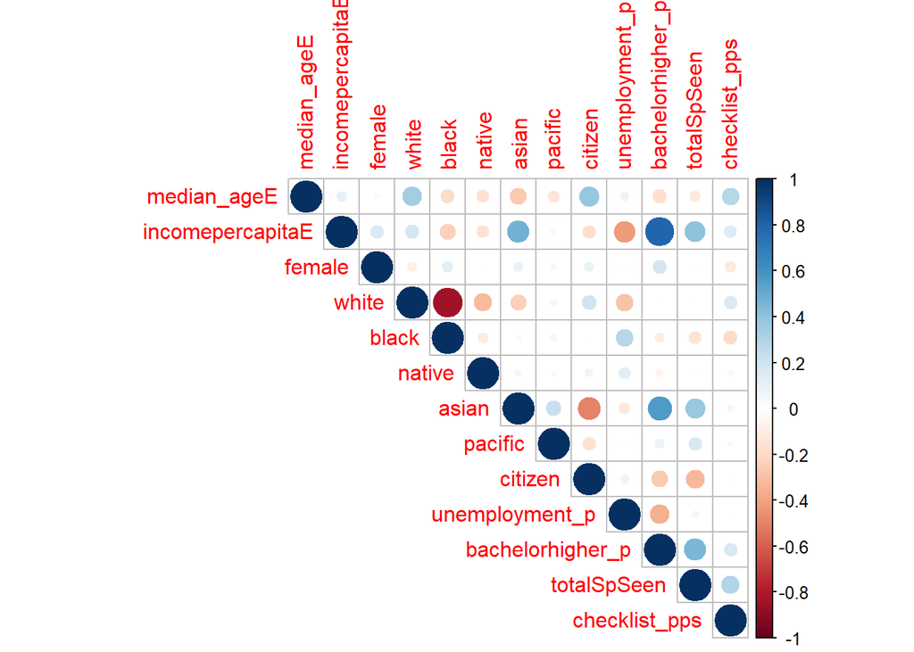

```r
census_ebird_filtered <- census_ebird_filtered %>%
  select(-c('county','State',"state","county_fips","checklist_n","GEOID","populationE","male","otherrace","Lesshighschool_p","highschool_p",  "college_p","checklists","modeledTotal","speciesDifference" )) %>%
  filter(checklist_pps<=1) %>%
  drop_na()

feature_cor=cor(census_ebird_filtered, method = "pearson")
corrplot(feature_cor, type="upper")
```

#### 3.2 Use linear regression to predict the popularity of bird watching in each county.

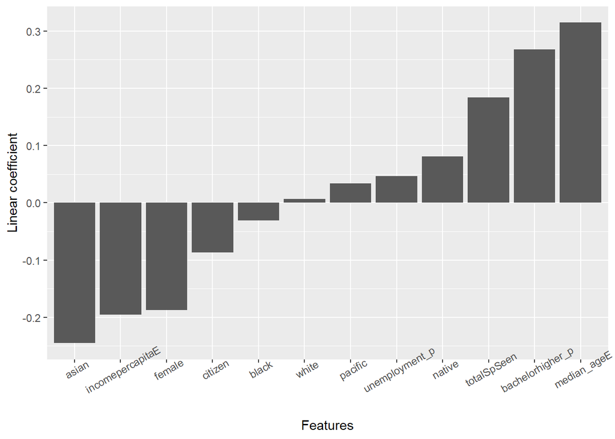

```r
normalize <- function(x) { return ((x - min(x)) / (max(x) - min(x)))}
census_ebird_nor <- census_ebird_filtered %>% mutate_at(vars(median_ageE:totalSpSeen), normalize)

#Use 80% samples to fit the model, use another 20% to test the model
set.seed(1)
in.trn <- sample.int(nrow(census_ebird_nor), 0.8*nrow(census_ebird_nor))
census_ebird_nor_trn <- census_ebird_nor[ in.trn,]
census_ebird_nor_tst <- census_ebird_nor[-in.trn,]

linearMod <- lm(checklist_pps ~ ., data=census_ebird_nor_trn)

linear_coeff <- as.data.frame(sort(linearMod$coefficients[-1]))
colnames(linear_coeff) <- 'coeff'
linear_coeff$feature <- rownames(linear_coeff)

ggplot(data=linear_coeff, aes(x=reorder(row.names(linear_coeff),coeff), y=coeff))+
  geom_bar(stat="identity")+
  theme(axis.text.x = element_text(angle = 30))+
  ylab("Linear coefficient")+
  xlab("Features")
```

```r
error=matrix(0,nrow=2,ncol=2, dimnames = list(c('linear','GBM'), c('training error','test error')))
error[1,1]=sqrt(sum((linearMod$residuals)^2)/length(linearMod$residuals))
```

```r
tstPred <- predict(linearMod, census_ebird_nor_tst)

linearMod_result <- as.data.frame(cbind(actuals=census_ebird_nor_tst$checklist_pps, predicteds=tstPred))

rmse_linear <- sqrt(mean((linearMod_result$actuals - linearMod_result$predicteds)^2))
error[1,2]=rmse_linear
sprintf('The RMSE for linear model on test data is %f',rmse_linear)
```

```
## [1] "The RMSE for linear model on test data is 0.062296"
```

#### 3.3 Use Gradient Boosting Machine to predict the popularity of bird watching in each county. Find the optimized parameters

```r
set.seed(66)
# train GBM model, find the range of iteration
gbm.fit <- gbm(
  formula = checklist_pps ~ .,
  distribution = "gaussian",
  data = census_ebird_nor_trn,
  n.trees = 10000,  #total number of train
  interaction.depth = 3,  #tree height, determine the number of splits
  shrinkage = 0.01,   #Learning rate
  cv.folds = 5,     #5 fold cross validation
  n.cores = NULL,
  verbose = FALSE  #don't print progress and performance indicators
  )
gbm.perf(gbm.fit, plot.it = FALSE,method = "cv")
```

```
## [1] 2100
```

```r
hyper_grid <- expand.grid(
  shrinkage = c(.005,0.01, .1),
  interaction.depth = c(1,5,10),
  n.minobsinnode = c(5, 10, 15),   # minimum number of observations in tree terminal nodes
  bag.fraction = c(0.65,0.8,0.9),
  optimal_trees = 0,               # a place to dump results
  min_RMSE = 0                     # a place to dump results
)


# grid search
for(i in 1:nrow(hyper_grid)) {

  set.seed(66)

  gbm.tune <- gbm(
    formula = checklist_pps ~ .,
    distribution = "gaussian",
    data = census_ebird_nor_trn,
    n.trees = 2000,
    interaction.depth = hyper_grid$interaction.depth[i],
    shrinkage = hyper_grid$shrinkage[i],
    n.minobsinnode = hyper_grid$n.minobsinnode[i],
    bag.fraction = hyper_grid$bag.fraction[i],
    train.fraction = .75,
    n.cores = NULL,
    verbose = FALSE
  )

  hyper_grid$optimal_trees[i] <- which.min(gbm.tune$valid.error)
  hyper_grid$min_RMSE[i] <- sqrt(min(gbm.tune$valid.error))
}

hyper_grid %>%
  dplyr::arrange(min_RMSE) %>%
  head(10)
```

|  | shrinkage | interaction.depth | n.minobsinnode | bag.fraction | optimal_trees | min_RMSE |
| --- | --- | --- | --- | --- | --- | --- |
| 1 | 0.010 | 10 | 5 | 0.65 | 1136 | 0.05815085 |
| 2 | 0.010 | 10 | 5 | 0.80 | 1306 | 0.05817272 |
| 3 | 0.010 | 5 | 5 | 0.80 | 1896 | 0.05833896 |
| 4 | 0.010 | 10 | 5 | 0.90 | 1864 | 0.05861208 |
| 5 | 0.010 | 5 | 15 | 0.90 | 1989 | 0.05871387 |
| 6 | 0.100 | 5 | 15 | 0.65 | 249 | 0.05878527 |
| 7 | 0.100 | 10 | 15 | 0.65 | 146 | 0.05878953 |
| 8 | 0.005 | 10 | 5 | 0.65 | 1999 | 0.05880478 |
| 9 | 0.005 | 10 | 5 | 0.90 | 1936 | 0.05881260 |
| 10 | 0.100 | 10 | 15 | 0.80 | 103 | 0.05884034 |

#### 3.4 Train the final GBM model, identify the most relevant variables

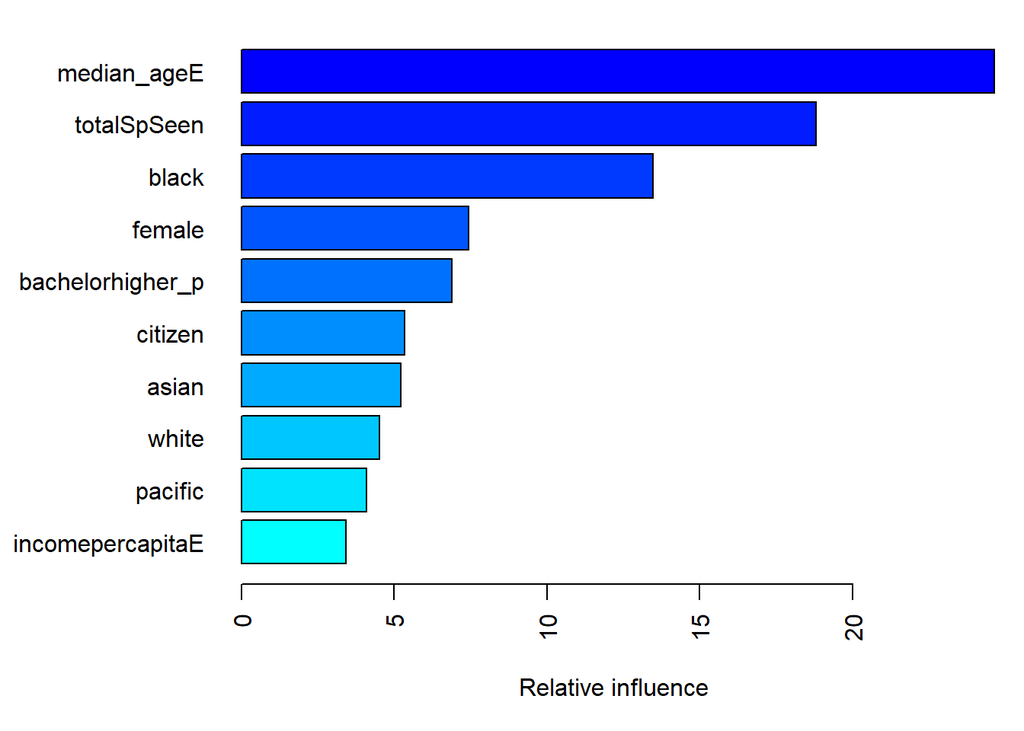

|  | var | rel.inf |
| --- | --- | --- |
| median_ageE | median_ageE | 24.641328 |
| totalSpSeen | totalSpSeen | 18.801576 |
| black | black | 13.479613 |
| female | female | 7.435628 |
| bachelorhigher_p | bachelorhigher_p | 6.878394 |
| citizen | citizen | 5.348987 |
| asian | asian | 5.232043 |
| white | white | 4.521422 |
| pacific | pacific | 4.099578 |
| incomepercapitaE | incomepercapitaE | 3.420782 |

[output cut: 2 more lines]

```r
set.seed(66)
# train GBM model
gbm.fit.final <- gbm(
  formula = checklist_pps ~ .,
  distribution = "gaussian",
  data = census_ebird_nor_trn,
  n.trees = 1136,
  interaction.depth = 10,
  shrinkage = 0.01,
  n.minobsinnode = 5,
  bag.fraction = .65,
  train.fraction = .75,
  n.cores = NULL,
  verbose = FALSE
  )

par(mar = c(5, 8, 1, 1))
summary(
  gbm.fit.final,
  cBars = 10,
  method = relative.influence, # also can use permutation.test.gbm
  las = 2
  )
```

```r
error[2,1] <- sqrt(sum((gbm.fit.final$fit-census_ebird_nor_trn$checklist_pps)^2)/length(census_ebird_nor_trn$checklist_pps))
```

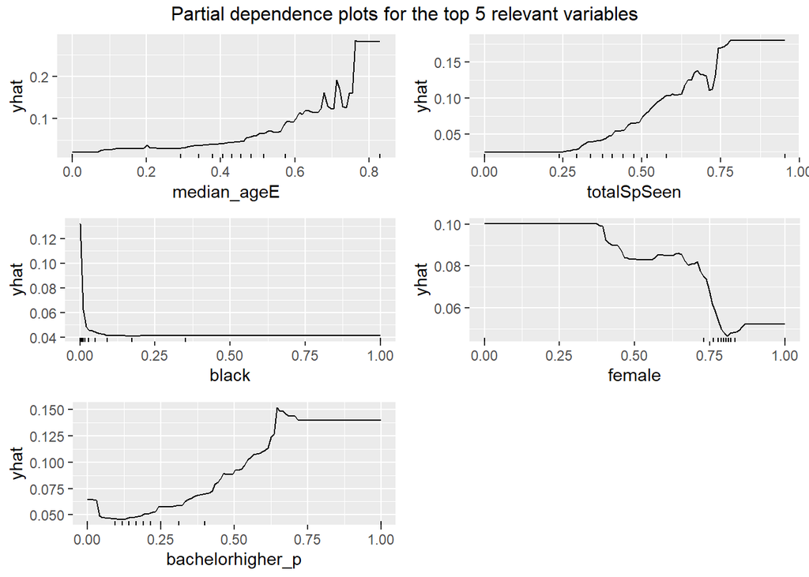

```r
fig1=gbm.fit.final %>%
  partial(
    pred.var = "median_ageE",
    n.trees = gbm.fit.final$n.trees,
    grid.resolution = 100
    ) %>%
  autoplot(rug = TRUE, train = census_ebird_nor_trn)

fig2=gbm.fit.final %>%
  partial(
    pred.var = "totalSpSeen",
    n.trees = gbm.fit.final$n.trees,
    grid.resolution = 100
    ) %>%
  autoplot(rug = TRUE, train = census_ebird_nor_trn)

fig3=gbm.fit.final %>%
  partial(
    pred.var = "black",
    n.trees = gbm.fit.final$n.trees,
    grid.resolution = 100
    ) %>%
  autoplot(rug = TRUE, train = census_ebird_nor_trn)

fig4=gbm.fit.final %>%
  partial(
    pred.var = "female",
    n.trees = gbm.fit.final$n.trees,
    grid.resolution = 100
    ) %>%
  autoplot(rug = TRUE, train = census_ebird_nor_trn)

fig5=gbm.fit.final %>%
  partial(
    pred.var = "bachelorhigher_p",
    n.trees = gbm.fit.final$n.trees,
    grid.resolution = 100
    ) %>%
  autoplot(rug = TRUE, train = census_ebird_nor_trn)

grid.arrange(fig1, fig2,fig3,fig4,fig5, top="Partial dependence plots for the top 5 relevant variables")
```

#### 3.5 Test the final GBM model on test data

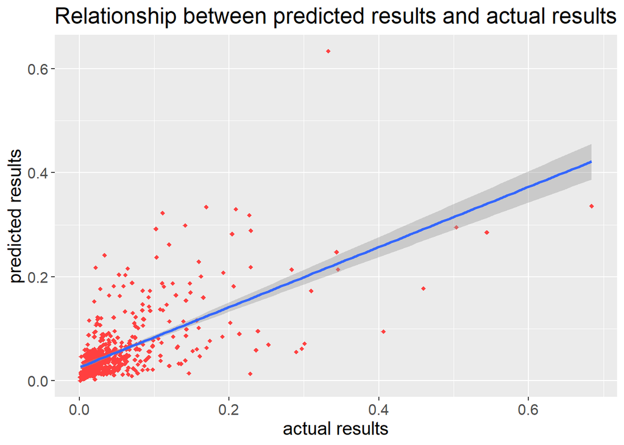

```r
gbm_pred <- predict(gbm.fit.final, n.trees = gbm.fit.final$n.trees, census_ebird_nor_tst)
error[2,2]=RMSE(gbm_pred, census_ebird_nor_tst$checklist_pps)

gbmMod_result <- as.data.frame(cbind(actuals=census_ebird_nor_tst$checklist_pps, predicteds=gbm_pred))

ggplot(gbmMod_result,aes(x=actuals, y=predicteds)) +
  geom_point(shape=18, color="brown1")+
  geom_smooth(method=lm)+
  labs(title="Relationship between predicted results and actual results",
       x="actual results", y = "predicted results")+
  theme(plot.title = element_text(hjust = 0.5),text = element_text(size=15))
```

```r
print(error)
```

```
##        training error test error
## linear     0.07157802 0.06229614
## GBM        0.03768957 0.05569177
```

### Conclusions:

### 1. Checklist number per person is a good metric for measuring popularity of bird watching.

### 2. Santa Cruz, AZ is a potential place to start the business. People prefer 1-3 hours trips in Spring on Saturday.

### 3. Our potential customers are more likely to be older man with higher education level.